# Pleural cfDNA Screening Array

DNAm Data Release Preparation

Paul Yousefi

29 September 2026

# Overview

This document prepares a versioned DNAm data release for the pleural cfDNA screening array study (project M2644). Raw IDAT files are read and processed using the `meffil` package: a samplesheet is generated, per-sample quality control (QC) is performed, failing samples are identified and removed, and quantile normalisation is applied to produce a clean beta-value matrix. Output files — including the samplesheet, detection p-values, beta matrix, and QC/normalisation reports — are written to a date-stamped release directory.

# Setup

Load required packages, configure directory paths for input data and release outputs, and set parallelisation options.

```r
packages <- c("meffil", "eval.save", "dplyr") #, "readxl")
lapply(packages, require, character.only=T)

dir <- paths
dir$release <- file.path(dir$output, "releases", format(Sys.Date(), "2026-09-29"))
#dir$release <- file.path(dir$output, "releases", format(Sys.Date(), "%Y-%m-%d"))
dir$reports <- file.path(dir$release, "derived/reports")

if(!dir.exists(dir$cache)) dir.create(dir$cache)
eval.save.dir(dir$cache)

options(mc.cores=16)
packageVersion("meffil")
```

Set the root path for the IDAT files (project M2644).

```r
dir$idats <- file.path(dir$data, "raw", "M2644")
dir$samplesheets <- file.path(dir$data, "raw", "180626_M2644")
```

Define all output file paths (samplesheet, QC report, detection p-values, PC fit plot, beta matrix, normalisation report) and create the required directory structure under the date-stamped release folder.

```r
file <- list()
file$samplesheet <- file.path(dir$release, "pleural-screening-samplesheet.csv")
file$qc.report <- file.path(dir$reports, "qc/pleural-screening.qc-report.html")
file$detect.p <- file.path(dir$release, "detect.p/pleural-screening.detection_p_values.rds")
file$pc.fit.plot <- file.path(dir$reports,"qc/pleural-screening.pc.fit.pdf")
file$betas <- file.path(dir$release, "betas/pleural-screening.betas.rds")
file$norm.report <- file.path(dir$reports, "normalization/pleural-screening.normalization-report.html")

# Recursively make directories for a vector of filepaths and
# return logic of success
make_dirs <- function(paths) {
  sapply(paths, function(p) {
    if (!dir.exists(p)) dir.create(p, recursive = TRUE)
    dir.exists(p)
  })
}

make_dirs(paths =
            c(dir$release,
            dir$reports,
            dirname(unlist(file))))
```

Set analysis parameters: report authorship metadata, the number of principal components to use for normalisation (`param$pc = 20`), and `run` flags that control whether cached intermediate objects are recomputed.

```r
param <- list()
param$verbose <- TRUE
param$report.author <- "Paul Yousefi"
param$report.study <- "pleural-cfDNA-screening-array"
param$pc <- 20
param$qc <- meffil.qc.parameters()

run <- list()
run$qc <- FALSE
run$qc.summary <- FALSE
run$detect.p <- FALSE
run$norm.objects <- FALSE
```

# Samplesheet

Automatically construct the meffil samplesheet by recursively scanning the IDAT directory for Sentrix barcode and position information.

```r
meffil.samplesheet <- meffil.create.samplesheet(dir$idats, recursive=TRUE)
meffil.samplesheet$subdir <- sub(".*/M2644/", "", meffil.samplesheet$Basename)
```

Read and combine the lab-provided per-plate sample sheets (one CSV per plate). Each file is parsed by skipping the `[Data]` header block, then all plates are row-bound. `Sample_Name` is renamed to `pid` to avoid collision with the meffil convention, and a new `Sample_Name` is constructed as `Sentrix_ID_Sentrix_Position` to match the meffil samplesheet key.

```r
file$lab.samplesheets <- list.files(dir$samplesheets,
                        pattern = "\\.csv$",
                        recursive = TRUE,
                        full.names = TRUE)

lab.samplesheet <- lapply(file$lab.samplesheets, function(f) {
    skip_n <- grep("^\\[Data\\]", readLines(f, warn = FALSE))
    dt <- data.table::fread(f, skip = skip_n)
    dt[, source_file := basename(f)]
    dt
}) |> data.table::rbindlist(fill = TRUE) |>
    dplyr::rename(pid = Sample_Name)|>
    mutate(Slide = as.character(Sentrix_ID))|>
    mutate(Sample_Name = paste(Slide, Sentrix_Position, sep="_"))|>
    dplyr::select(Sample_Name, pid, source_file)

# fix one pid case error
# Was 'c1615MR' should be 'C1615MR'
err <- grep("1615MR", lab.samplesheet$pid)
lab.samplesheet$pid[err]
```

```
> [1] "c1615MR"
```

```r
lab.samplesheet$pid[err] <- "C1615MR"
lab.samplesheet$pid[err]
```

```
> [1] "C1615MR"
```

Join the meffil-derived samplesheet with the lab samplesheet on `Sample_Name` to attach participant IDs (`pid`) and plate source information to each array position. The result is stored as `samplesheet` and written to the release directory.

```r
samplesheet <- meffil.samplesheet |>
                left_join(lab.samplesheet, by = c("Sample_Name"))
data.table::fwrite(samplesheet,file = file$samplesheet)
```

# Quality Control

Run per-sample QC using `meffil.qc()`. This extracts intensities from each IDAT pair and evaluates a battery of control probes, dye-bias, sex prediction, detection p-values, and bead-count metrics. Results are cached via `eval.save` to avoid recomputation on subsequent runs.

```r
meffil.list.featuresets()

eval.save({
    qc.objects <- meffil.qc(samplesheet,
                    verbose = param$verbose,
                    detection.threshold = 0.01) ## default but specifying for clarity
}, "qc.objects", redo=run$qc)
qc.objects <- eval.ret("qc.objects")
```

Summarise the QC results across all samples and probes using `meffil.qc.summary()`. The summary identifies samples and CpGs that fail QC thresholds and is used both for reporting and for downstream sample exclusion.

```r
param$qc

eval.save({
    qc.summary <- meffil.qc.summary(qc.objects,
                    verbose = param$verbose,
                    parameters = param$qc)
}, "qc.summary", redo=run$qc.summary)
qc.summary <- eval.ret("qc.summary")
```

Generate an HTML QC report from the summary object. The report is written to both the release directory and the `docs/` folder for version-controlled archiving.

- **NOTE** report code below didn’t want to run in rendering to html but full script was run in batch mode

```r
sapply(
    list(file$qc.report,
        file.path(dir$scripts, "docs", basename(file$qc.report))),
            function(i){
                meffil.qc.report(
                qc.summary,
                output.file = i,
                author = param$report.author,
                study = param$report.study)
            }
    )
```

SNP probes on the array can be used to verify sample identity against independent genotype data. The code below (commented out) exports the SNP probe names for use with PLINK, and would load the resulting genotype calls back into R. This step is retained for reference but was not applied in this release. The pipeline continues directly to sample filtering.

```r
#featureset <- qc.objects[[1]]$featureset
#writeLines(meffil.snp.names(featureset), con = file$snp)

## # from https://github.com/perishky/meffil/wiki/Sample-QC
## system("plink --bfile dataset --extract snp-names.txt --recode A --out genotypes")
##
## genotypes <- meffil.extract.genotypes("genotypes.raw")
## genotypes <- genotypes[,match(samplesheet$Sample_Name, colnames(genotypes))]

#stop("--- stopping here ---", call. = FALSE)
```

# Sample Filtering

Extract flagged samples from the QC summary and restrict to those failing on interpretable technical issues: dye-bias, methylated vs unmethylated signal ratio, X–Y ratio, low bead numbers, high detection p-values, sex mismatch, genotype mismatch, and bisulfite conversion control probes.

```r
outlier <- qc.summary$bad.samples
table(outlier$issue)
```

```
>
>     Control probe (dye.bias)  Control probe (spec1.ratio)
>                            2                            3
> Control probe (spec1.ratio1) Control probe (spec1.ratio2)
>                            1                            3
>  Control probe (spec2.ratio)            Detection p-value
>                            4                           14
>   Methylated vs Unmethylated            X-Y ratio outlier
>                            6                            6
```

```r
index <- outlier$issue %in% c("Control probe (dye.bias)",
                              "Methylated vs Unmethylated",
                              "X-Y ratio outlier",
                              "Low bead numbers",
                              "Detection p-value",
                              "Sex mismatch",
                              "Genotype mismatch",
                              "Control probe (bisulfite1)",
                              "Control probe (bisulfite2)")

outlier <- outlier[index,]
outlier
```

```
>                              sample.name                      issue
> 208661850039_R08C03  208661850039_R08C03 Methylated vs Unmethylated
> 189                  208661850041_R04C02          X-Y ratio outlier
> 208661850041_R15C01  208661850041_R15C01          Detection p-value
> 208661850041_R15C02  208661850041_R15C02          Detection p-value
> 208661850042_R03C03  208661850042_R03C03          Detection p-value
> 208661850042_R05C01  208661850042_R05C01 Methylated vs Unmethylated
> 208661850042_R05C011 208661850042_R05C01          Detection p-value
> 256                  208661850042_R07C01          X-Y ratio outlier
> 208661850042_R07C02  208661850042_R07C02          Detection p-value
> 208661850043_R04C02  208661850043_R04C02 Methylated vs Unmethylated
> 208661850043_R14C02  208661850043_R14C02 Methylated vs Unmethylated
> 12577                208661850044_R01C01   Control probe (dye.bias)
> 208661850044_R01C01  208661850044_R01C01          Detection p-value
> 208661850044_R01C02  208661850044_R01C02          Detection p-value
> 208661850044_R01C03  208661850044_R01C03          Detection p-value
> 12582                208661850044_R02C03   Control probe (dye.bias)
> 208661850044_R02C03  208661850044_R02C03          Detection p-value
> 208661850044_R03C03  208661850044_R03C03          Detection p-value
> 219                  208661850044_R04C01          X-Y ratio outlier
> 224                  208661850044_R06C01          X-Y ratio outlier
> 208661850044_R12C01  208661850044_R12C01 Methylated vs Unmethylated
> 232                  208661850044_R12C01          X-Y ratio outlier
> 208661850045_R05C01  208661850045_R05C01          Detection p-value
> 208661850045_R07C02  208661850045_R07C02          Detection p-value
> 208661850045_R14C02  208661850045_R14C02          Detection p-value
> 142                  208661850045_R14C02          X-Y ratio outlier
> 208661850045_R16C01  208661850045_R16C01 Methylated vs Unmethylated
> 208661850045_R16C011 208661850045_R16C01          Detection p-value
```

```r
length(unique(outlier$sample.name))
```

```
> [1] 22
```

```r
# these were 5 further "Methylated vs Unmethylated" outliers that only
# came up after dropping the first time. They still look like outliers
# so manually dropping them in cleaning now

# there was also 1 controll probe mean outlier in terms of it's 'spec1.ratio1'
# value, "208661850045_R15C02", that somehow didn't get dropped automatically
# so doing so now.

# 29 Sep 2026 - added one more sample to drop based on `dnam-release-summary`
# which observed that `208661850039_R03C01` had per-sample-median correlation <0.5
bad.ids <-
    c("208661850045_R09C03",
    "208661850045_R10C02",
    "208661850041_R09C01",
    "208661850044_R09C02",
    "208661850042_R15C02",
    "208661850045_R15C02",
    "208661850039_R03C01") ## added 29 Sept 2026

outlier <- unique(c(outlier$sample.name, bad.ids))
length(outlier)
```

```
> [1] 29
```

Remove all flagged samples from the QC object list and from the samplesheet. The cleaned samplesheet is saved with a `.clean.csv` suffix to distinguish it from the initial full samplesheet.

```r
length(qc.objects)
```

```
> [1] 336
```

```r
qc.objects <- meffil.remove.samples(qc.objects, outlier)
length(qc.objects)
```

```
> [1] 307
```

```r
samplesheet <- subset(samplesheet,
                    !Sample_Name %in% outlier)

file$samplesheet <- sub("\\.csv$", ".clean.csv", file$samplesheet)
data.table::fwrite(samplesheet,file = file$samplesheet)
```

Recompute the QC summary on the cleaned sample set to confirm that no further outliers are present after exclusion.

```r
qc.summary <- meffil.qc.summary(qc.objects, verbose = param$verbose)
```

```
> [meffil.qc.summary] Tue Sep 29 15:09:28 2026 Sex summary TRUE
> [meffil.qc.summary] Tue Sep 29 15:09:29 2026 Meth vs unmeth summary
```

```
> [meffil.qc.summary] Tue Sep 29 15:09:29 2026 Control means summary
> [meffil.qc.summary] Tue Sep 29 15:09:29 2026 Sample detection summary
> [meffil.qc.summary] Tue Sep 29 15:09:37 2026 CpG detection summary
> [meffil.qc.summary] Tue Sep 29 15:09:41 2026 Sample bead numbers summary
> [meffil.qc.summary] Tue Sep 29 15:09:43 2026 CpG bead numbers summary
> [meffil.qc.summary] Tue Sep 29 15:09:43 2026 Cell count summary
> [meffil.qc.summary] Tue Sep 29 15:09:43 2026 Genotype concordance
```

Generate a second QC report reflecting the post-exclusion sample set. This is the report that accompanies the released data.

- **NOTE** report code below didn’t want to run in rendering to html but full script was run in batch mode

```r
file$qc.report <- sub("\\.html$", ".clean.html", file$qc.report)
sapply(
    list(file$qc.report,
        file.path(dir$scripts, "docs", basename(file$qc.report))),
            function(i){
                meffil.qc.report(
                qc.summary,
                output.file = i,
                author = param$report.author,
                study = param$report.study)
            }
    )
```

# CpG Filtering

Tabulate the CpGs flagged in the QC summary by failure reason (e.g. low detection p-values). These probes are not removed here but are passed to `meffil.normalize.samples()` via the `cpglist.remove` argument during normalisation, ensuring they are excluded from the final beta matrix.

```r
# probes not meeting detection p-value thresholds
# these are removed below prior to normalization  in meffil.normalize.samples()
# using the cpglist.remove argument
table(qc.summary$bad.cpgs$issue)
```

```
>
> Detection p-value
>             26938
```

# Detection P-values

Extract per-sample, per-CpG detection p-values from the QC objects and save them as an RDS file. Detection p-values indicate whether a probe signal is distinguishable from background and are used downstream to mask unreliable methylation calls.

```r
# runs if detect.p doesn't exist or run is TRUE
if(!file.exists(file$detect.p) || run$detect.p){
    qc.objects |>
        meffil.load.detection.pvalues(verbose = param$verbose) |>
        readr::write_rds(file = file$detect.p)
}
```

# Normalisation

Plot the variance explained by successive principal components of the control-probe intensities to inform the choice of PC count for functional normalisation. Visual inspection of this elbow plot was used to select `param$pc = 20`.

```r
y <- meffil.plot.pc.fit(qc.objects)

sapply(
    list(file$pc.fit.plot,
        file.path(dir$scripts, "docs", basename(file$pc.fit.plot))),
            function(i){
                ggsave(y$plot,
                    filename = i,
                    height = 6,
                    width = 6)
            }
    )
```

Apply functional normalisation using quantile regression on the selected number of control-probe PCs (`meffil.normalize.quantiles()`). Beta values are then extracted with `meffil.normalize.samples()`, excluding CpGs identified as poor quality in the QC summary. The resulting beta matrix is saved as an RDS file.

```r
eval.save({
    norm.objects <- meffil.normalize.quantiles(
        qc.objects,
        number.pcs=param$pc, # set to 20 @top by visual inspection of pc plot
        verbose = param$verbose)
}, "norm.objects", redo=run$norm.objects)
norm.objects <- eval.ret("norm.objects")

beta.meffil <- meffil.normalize.samples(
    norm.objects,
    just.beta=T,
    cpglist.remove=qc.summary$bad.cpgs$name, ## removing
    verbose = param$verbose)

beta.meffil |>
    readr::write_rds(file = file$betas)
```

Compute principal components of the normalised beta matrix using autosomal CpG sites only. These PCs are used in the normalisation summary to assess residual technical variation after normalisation.

```r
pcs <- meffil.methylation.pcs(
    beta.meffil,
    sites=meffil.get.autosomal.sites("msa"),
    verbose = param$verbose)
```

```
> [meffil.methylation.pcs] Tue Sep 29 15:13:20 2026 Calculating CpG variance
> [meffil.methylation.pcs] Tue Sep 29 15:13:22 2026 Calculating beta PCs
```

Summarise the normalisation by testing for association between the normalisation PCs and sample phenotype/batch variables. A batch threshold of 0.01 is used to flag potential residual confounding.

```r
parameters <- meffil.normalization.parameters(norm.objects)
parameters$batch.threshold <- 0.01
norm.summary <- meffil.normalization.summary(
    norm.objects=norm.objects,
    pcs=pcs,
    parameters=parameters,
    verbose = param$verbose)
```

```
> [meffil.plot.control.batch] Tue Sep 29 15:13:25 2026 Extracting batch variables
> [meffil.plot.control.batch] Tue Sep 29 15:13:25 2026 Testing associations
> [meffil.plot.probe.batch] Tue Sep 29 15:15:39 2026 Extracting batch variables
> [meffil.plot.probe.batch] Tue Sep 29 15:15:39 2026 Testing associations
```

Generate an HTML normalisation report and write it to both the release directory and `docs/`.

```r
sapply(
    list(file$norm.report,
        file.path(dir$scripts, "docs", basename(file$norm.report))),
            function(i){
                meffil.normalization.report(
                    norm.summary,
                    output.file = i,
                author = param$report.author,
                study = param$report.study)
            }
    )
```

# Sample–Sample Correlation

```r
sample.cor <- cor(beta.meffil)
```

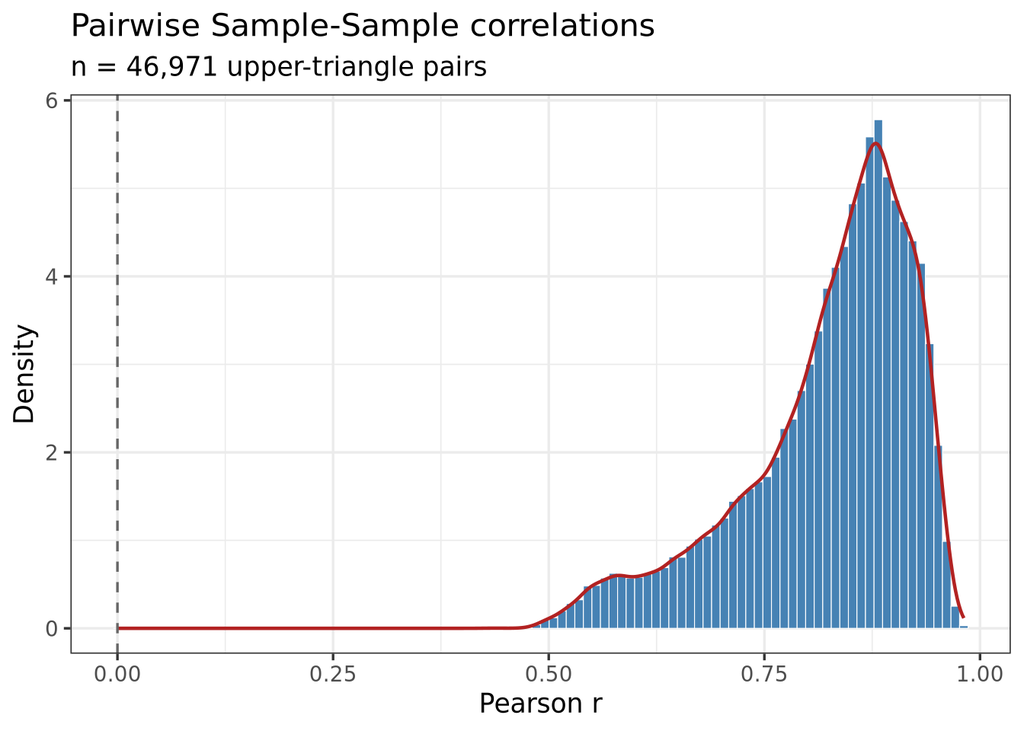

```r
sample.cor.offdiag <- sample.cor[upper.tri(sample.cor)]

ggplot2::ggplot(data.frame(r = sample.cor.offdiag), ggplot2::aes(x = r)) +
    ggplot2::geom_histogram(
        ggplot2::aes(y = ggplot2::after_stat(density)),
        bins = 100,
        fill = "steelblue", colour = "white", linewidth = 0.2) +
    ggplot2::geom_density(colour = "firebrick", linewidth = 0.8) +
    ggplot2::geom_vline(xintercept = 0, linetype = "dashed", colour = "grey40") +
    ggplot2::labs(
        title = "Pairwise Sample-Sample correlations",
        subtitle = sprintf("n = %s upper-triangle pairs",
                           format(length(sample.cor.offdiag), big.mark = ",")),
        x = "Pearson r",
        y = "Density") +
    ggplot2::theme_bw(base_size = 13)
```